# SLP Estimations: Data Analysis

# Packages

```r
library(rio) # install.packages("rio")
library(tidyverse) # install.packages("tidyverse")
library(corrr) # install.packages("corrr")
library(performance) # install.packages("performance")
library(furniture) #install.packages("furniture")
library(see) # install.packages("see")
library(patchwork) # install.packages("patchwork")
library(ggridges) #install.packages("ggridges")
library(rmcorr) #install.packages("rmcorr")
library(irr) #install.packages("irr")
library(ggpubr) #install.packages("ggpubr")
```

# Importing the datasets

This chunk contains all of the dataframes needed for the stat analysis.

```r
# This data is used for question #1
IntSpeakerRatings <- rio::import("Shared Data/SpeakerIntelligibility.csv")

# This data is used for question #2 & #4
slp_Demographics <- rio::import("Shared Data/SLP_Demographics.csv")
slp_Correlation <- rio::import("Shared Data/SLP_Correlation.csv")

slp_Correlation <- slp_Correlation %>%
  dplyr::mutate(slpID=as.factor(slpID))

# This data is used for question #3
naive_Demographics <- rio::import("Shared Data/NaiveListener_Demographics.csv")
naive_Correlation <- rio::import("Shared Data/NaiveListener_Correlation.csv")

naive_Correlation <- naive_Correlation %>%
  dplyr::mutate(ListenerID=as.factor(ListenerID))

# Creating SLP Long Data - Used for descriptive statistics.
slpLong <- slp_Correlation %>%
  dplyr::select(!c(slp_VAS.Rel,slp_EST.Rel)) %>%
  dplyr::rename(VAS = slp_VAS,
                EST = slp_EST) %>%
  pivot_longer(cols = VAS:EST,
               names_to = "Method",
               values_to = "ratings")

slpWide <- pivot_wider(slpLong, names_from = Method, values_from = ratings)
```

# Descriptive Stats

## SLP Demographics

```r
slp_Demographics %>%
  furniture::table1(age, gender, race, ethnicity, yearsExp, medSetting)
```

|  |  | Mean/Count (SD/%) |
| --- | --- | --- |
| 1 |  | n = 21 |
| 2 | age |  |
| 3 |  | 33.8 (10.2) |
| 4 | gender |  |
| 5 | Man | 3 (14.3%) |
| 6 | Prefer not to say | 1 (4.8%) |
| 7 | Woman | 17 (81%) |
| 8 | race |  |
| 9 | Asian American | 1 (4.8%) |
| 10 | White/Caucasian | 20 (95.2%) |

[output cut: 14 more lines]

## Naive Listener Demographics

```r
naive_Demographics %>%
  furniture::table1(age, gender, race, ethnicity, famSLHDs, type = c("simple", "condensed"))
```

|  |  | Mean/Count (SD/%) |
| --- | --- | --- |
| 1 |  | n = 70 |
| 2 | age | 34.8 (13.9) |
| 3 | gender |  |
| 4 | Agender | 2.9% |
| 5 | Genderqueer | 1.4% |
| 6 | Man | 52.9% |
| 7 | Non-Binary | 2.9% |
| 8 | Woman | 40% |
| 9 | race |  |
| 10 |  | 1.4% |

[output cut: 9 more lines]

## SLP descriptives

```r
# Print mean and SD
MeanSLPInt <- slpLong %>%
  dplyr::group_by(Speaker, Method) %>%
  dplyr::summarize(Intelligibility = mean(ratings, na.rm =T), IntSD = sd(ratings, na.rm = T),
                   .groups = "rowwise")

MeanSLPInt
```

| Speaker | Method | Intelligibility | IntSD |
| --- | --- | --- | --- |
| AF1 | EST | 82.80952 | 12.006744 |
| AF1 | VAS | 79.16333 | 24.698511 |
| AF9 | EST | 12.71429 | 9.834342 |
| AF9 | VAS | 7.80100 | 8.631764 |
| ALSF6 | EST | 26.66667 | 20.696215 |
| ALSF6 | VAS | 30.32684 | 25.438250 |
| ALSF7 | EST | 51.71429 | 27.426525 |
| ALSF7 | VAS | 66.01190 | 24.386397 |
| ALSF9 | EST | 38.23810 | 23.541251 |
| ALSF9 | VAS | 39.75619 | 21.554421 |

[output cut: 30 more lines]

```r
NA
```

## Naive Listener Descriptives

```r
naive_Correlation %>%
  dplyr::group_by(SpeakerID) %>%
  dplyr::summarize(OT = mean(naive_OT), OT_SD = sd(naive_OT), VAS = mean(naive_VAS), VAS_SD = sd(naive_VAS))
```

| SpeakerID | OT | OT_SD | VAS | VAS_SD |
| --- | --- | --- | --- | --- |
| AF1 | 71.90650 | 28.683926 | 65.386250 | 28.792887 |
| AF9 | 11.46558 | 5.592500 | 7.089167 | 9.240587 |
| ALSF6 | 24.16667 | 13.184476 | 18.872500 | 19.125099 |
| ALSF7 | 52.98827 | 9.559886 | 45.298000 | 32.691107 |
| ALSF9 | 38.61538 | 10.247931 | 12.084000 | 12.616261 |
| ALSM1 | 66.32479 | 22.869810 | 76.972500 | 14.837058 |
| ALSM4 | 72.09402 | 25.992885 | 72.712500 | 12.136395 |
| AM1 | 63.10256 | 9.703358 | 37.339000 | 23.195461 |
| AM3 | 61.15995 | 10.187668 | 53.405714 | 15.144449 |
| AM5 | 52.57915 | 29.389919 | 60.450000 | 17.640665 |

[output cut: 10 more lines]

## SLP Distribution Plot for EST

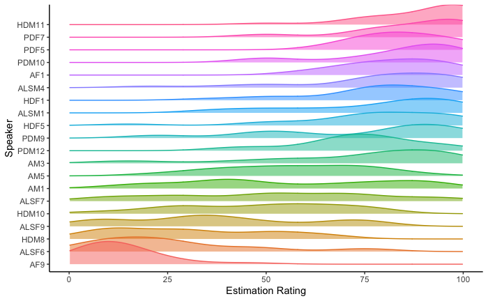

```r
distributionData <- slp_Correlation %>%
  dplyr::mutate(Speaker = fct_relevel(Speaker, levels = "AF9", "ALSF6", "HDM8", "ALSF9", "HDM10", "ALSF7", "AM1", "AM5", "AM3", "PDM12", "PDM9", "HDF5", "ALSM1", "HDF1", "ALSM4", "AF1", "PDM10", "PDF5", "PDF7", "HDM11"))

slp_EST.DistPlot <- distributionData %>%
  ggplot() +
  aes(x = slp_EST,
      y = Speaker,
      fill = Speaker,
      color = Speaker) +
  xlim(c(0,100)) +
  xlab("Estimation Rating") +
  geom_density_ridges(alpha = 0.5) +
  theme_classic() +
  theme(legend.position = "none")

slp_EST.DistPlot
```

## SLP Distribution Plot for VAS

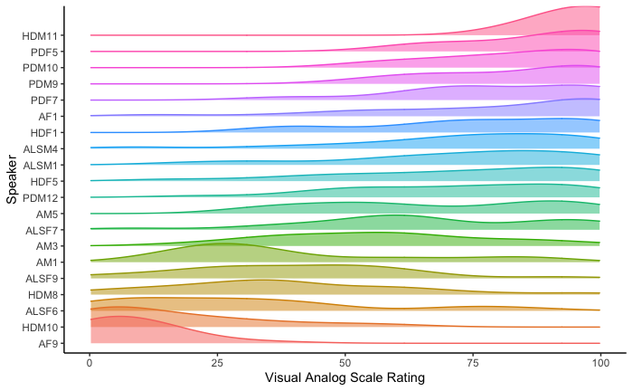

```r
distributionData <- slp_Correlation %>%
  dplyr::mutate(Speaker = fct_relevel(Speaker, levels = "AF9", "HDM10", "ALSF6", "HDM8", "ALSF9", "AM1", "AM3", "ALSF7", "AM5", "PDM12", "HDF5", "ALSM1", "ALSM4", "HDF1", "AF1", "PDF7", "PDM9", "PDM10", "PDF5", "HDM11"))

slp_VAS.DistPlot <- distributionData %>%
  ggplot() +
  aes(x = slp_VAS,
      y = Speaker,
      fill = Speaker,
      color = Speaker) +
  xlim(c(0,100)) +
  xlab("Visual Analog Scale Rating") +
  geom_density_ridges(alpha = 0.5) +
  theme_classic() +
  theme(legend.position = "none")

slp_VAS.DistPlot
```

## Combining and saving Distribution Plot

```r
DistributionPlot <- ggpubr::ggarrange(slp_EST.DistPlot, slp_VAS.DistPlot, ncol = 2, labels = c("A", "B"), nrow = 1)
```

```
Removed 17 rows containing non-finite values (stat_density_ridges).
```

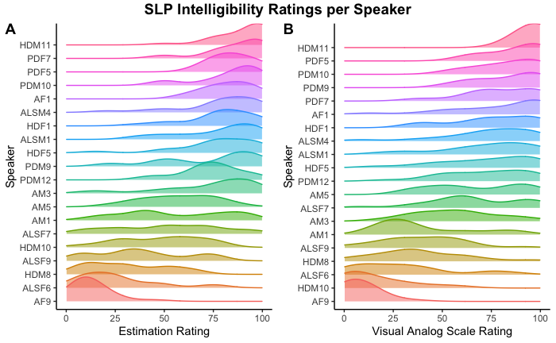

```r
DistributionPlot <- annotate_figure(DistributionPlot, top = text_grob("SLP Intelligibility Ratings per Speaker",
               face = "bold", size = 14))

DistributionPlot

ggsave(filename = "Plots/Distribution_Plot.png", plot = DistributionPlot, height = 5, width = 10, unit = "in")
```

# Research Question #1

Q1: Are SLP estimates of speech intelligibility predictive of naive listener estimations?

Since the speakers are the common variable between the SLP and Naive listener task, intelligibility scores for each method were calculated by speaker.

This first block explores the correlation matrix of SLP and Naive listener intelligibility ratings.

```r
IntCorrelation <- IntSpeakerRatings %>%
  dplyr::select(!SpeakerID)

IntCorr_Matrix <- corrr::correlate(IntCorrelation,
                                   method = "pearson",
                                   use = "pairwise.complete.obs",
                                   quiet = T)
IntCorr_Matrix
```

| term | naive_VAS | naive_OT | slp_EST | slp_VAS |
| --- | --- | --- | --- | --- |
| naive_VAS | NA | 0.9083456 | 0.9201733 | 0.9300065 |
| naive_OT | 0.9083456 | NA | 0.9554978 | 0.8757991 |
| slp_EST | 0.9201733 | 0.9554978 | NA | 0.9047387 |
| slp_VAS | 0.9300065 | 0.8757991 | 0.9047387 | NA |

This next block is modeling SLP estimation as predictor of naive listener OT.

```r
SLP_ESTmodel <- lm(naive_OT ~ slp_EST, data= IntSpeakerRatings)
summary(SLP_ESTmodel)
```

```
Call:
lm(formula = naive_OT ~ slp_EST, data = IntSpeakerRatings)

Residuals:
    Min      1Q  Median      3Q     Max
-9.4903 -4.8104 -0.5625  3.6255 10.4641

Coefficients:
            Estimate Std. Error t value Pr(>|t|)
(Intercept)  7.22884    4.02761   1.795   0.0895 .
slp_EST      0.81714    0.05946  13.742 5.53e-11 ***
---
Signif. codes:  0 ‘***’ 0.001 ‘**’ 0.01 ‘*’ 0.05 ‘.’ 0.1 ‘ ’ 1

Residual standard error: 5.86 on 18 degrees of freedom
Multiple R-squared:  0.913, Adjusted R-squared:  0.9081
F-statistic: 188.8 on 1 and 18 DF,  p-value: 5.53e-11
```

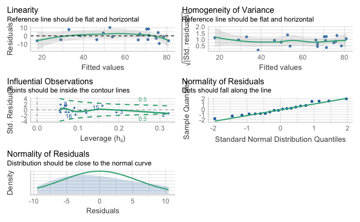

```r
performance::check_model(SLP_ESTmodel)
```

This next block is examining SLP VAS as a predictor of naive listener OT.

```r
SLP_VASmodel <- lm(naive_OT ~ slp_VAS, data = IntSpeakerRatings)
summary(SLP_VASmodel)
```

```
Call:
lm(formula = naive_OT ~ slp_VAS, data = IntSpeakerRatings)

Residuals:
     Min       1Q   Median       3Q      Max
-13.7789  -8.5903   0.0229   5.4079  18.1889

Coefficients:
            Estimate Std. Error t value Pr(>|t|)
(Intercept) 17.12411    5.91533   2.895  0.00965 **
slp_VAS      0.68657    0.08919   7.698 4.22e-07 ***
---
Signif. codes:  0 ‘***’ 0.001 ‘**’ 0.01 ‘*’ 0.05 ‘.’ 0.1 ‘ ’ 1

Residual standard error: 9.588 on 18 degrees of freedom
Multiple R-squared:  0.767, Adjusted R-squared:  0.7541
F-statistic: 59.26 on 1 and 18 DF,  p-value: 4.22e-07
```

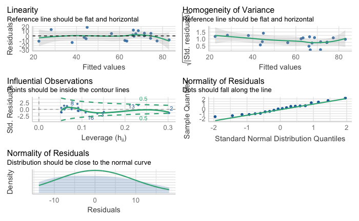

```r
performance::check_model(SLP_VASmodel)
```

Naive OT Model comparisons

```r
performance::compare_performance(SLP_ESTmodel, SLP_VASmodel, rank = T)
```

```
# Comparison of Model Performance Indices

Name         | Model |    R2 | R2 (adj.) |  RMSE | Sigma | AIC weights | BIC weights | Performance-Score
--------------------------------------------------------------------------------------------------------
SLP_ESTmodel |    lm | 0.913 |     0.908 | 5.559 | 5.860 |       1.000 |       1.000 |           100.00%
SLP_VASmodel |    lm | 0.767 |     0.754 | 9.096 | 9.588 |     < 0.001 |     < 0.001 |             0.00%
```

```r
performance::test_performance(SLP_ESTmodel, SLP_VASmodel)
```

```
Name         | Model |      BF
------------------------------
SLP_ESTmodel |    lm |
SLP_VASmodel |    lm | < 0.001
Each model is compared to SLP_ESTmodel.
```

This next block is examining SLP EST as a predictor of naive listener VAS.

```r
SLP_ESTmodel_VAS <- lm(naive_VAS ~ slp_EST, data = IntSpeakerRatings)
summary(SLP_ESTmodel_VAS)
```

```
Call:
lm(formula = naive_VAS ~ slp_EST, data = IntSpeakerRatings)

Residuals:
    Min      1Q  Median      3Q     Max
-23.100  -5.915   2.525   6.108  14.683

Coefficients:
            Estimate Std. Error t value Pr(>|t|)
(Intercept) -9.98814    6.63870  -1.505     0.15
slp_EST      0.97734    0.09801   9.972 9.33e-09 ***
---
Signif. codes:  0 ‘***’ 0.001 ‘**’ 0.01 ‘*’ 0.05 ‘.’ 0.1 ‘ ’ 1

Residual standard error: 9.659 on 18 degrees of freedom
Multiple R-squared:  0.8467,    Adjusted R-squared:  0.8382
F-statistic: 99.43 on 1 and 18 DF,  p-value: 9.331e-09
```

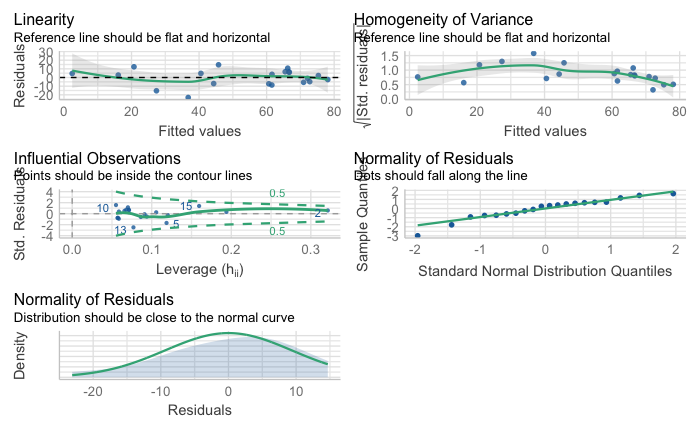

```r
performance::check_model(SLP_ESTmodel_VAS)
```

This block examines SLP VAS as a predictor of naive listener VAS.

```r
SLP_VASmodel_VAS <- lm(naive_VAS ~ slp_VAS, data = IntSpeakerRatings)
summary(SLP_VASmodel_VAS)
```

```
Call:
lm(formula = naive_VAS ~ slp_VAS, data = IntSpeakerRatings)

Residuals:
    Min      1Q  Median      3Q     Max
-20.550  -7.119   2.056   6.003  14.940

Coefficients:
            Estimate Std. Error t value Pr(>|t|)
(Intercept) -3.36401    5.59426  -0.601    0.555
slp_VAS      0.90548    0.08435  10.735 2.96e-09 ***
---
Signif. codes:  0 ‘***’ 0.001 ‘**’ 0.01 ‘*’ 0.05 ‘.’ 0.1 ‘ ’ 1

Residual standard error: 9.068 on 18 degrees of freedom
Multiple R-squared:  0.8649,    Adjusted R-squared:  0.8574
F-statistic: 115.2 on 1 and 18 DF,  p-value: 2.965e-09
```

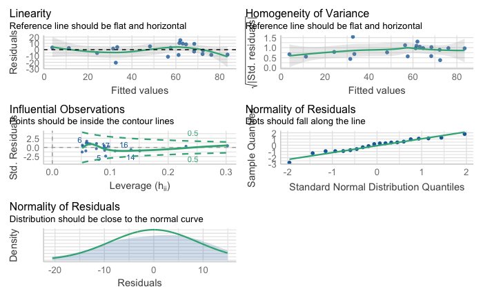

```r
performance::check_model(SLP_VASmodel_VAS)
```

Naive VAS model comparison

```r
performance::compare_performance(SLP_ESTmodel_VAS, SLP_VASmodel_VAS, rank = T)
```

```
# Comparison of Model Performance Indices

Name             | Model |    R2 | R2 (adj.) |  RMSE | Sigma | AIC weights | BIC weights | Performance-Score
------------------------------------------------------------------------------------------------------------
SLP_VASmodel_VAS |    lm | 0.865 |     0.857 | 8.603 | 9.068 |       0.780 |       0.780 |           100.00%
SLP_ESTmodel_VAS |    lm | 0.847 |     0.838 | 9.164 | 9.659 |       0.220 |       0.220 |             0.00%
```

```r
performance::test_performance(SLP_ESTmodel_VAS, SLP_VASmodel_VAS)
```

```
Name             | Model |   BF
-------------------------------
SLP_ESTmodel_VAS |    lm |
SLP_VASmodel_VAS |    lm | 3.54
Each model is compared to SLP_ESTmodel_VAS.
```

## R1 Plot

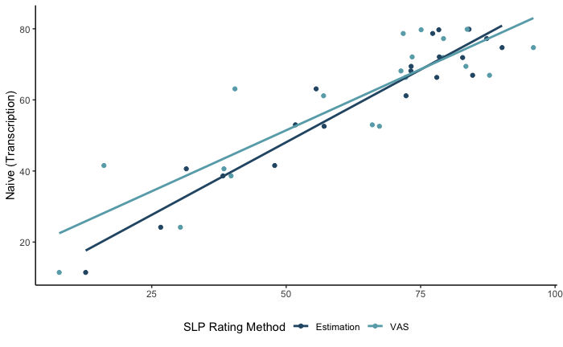

```r
## custom colors
my_pal <- rcartocolor::carto_pal(n = 7, name = "Teal")[c(7, 4, 3, 2, 4)]

IntSpeakerRatings_Long <- tidyr::pivot_longer(IntSpeakerRatings,
                                              cols = slp_EST:slp_VAS,
                                              names_to = "Method",
                                              values_to = "rating")

IntSpeakerRatings_Long <- IntSpeakerRatings_Long %>%
  dplyr::mutate(Method = recode(Method, slp_EST = "Estimation", slp_VAS = "VAS"))

NaiveOT_plot <- IntSpeakerRatings_Long %>%
  ggplot() +
  aes(x = rating,
      y = naive_OT,
      color = Method) +
  geom_point() +
  geom_smooth(method = "lm",
              se = F) +
  ylab("Naive (Transcription)") +
  labs(color = "SLP Rating Method") +
  scale_color_manual(values = my_pal) +
  theme_classic() +
  theme(legend.position = "bottom",
        axis.title.x=element_blank())

NaiveOT_plot

ggsave("Plots/RQ1_ScatterPlot.png", plot = last_plot(),height = 10, width = 10, units = "in", scale = .35)
```

# Research Question #2

Q2: Is there a strong relationship between SLP intelligibility approximations with SLP VAS intelligibility ratings?

```r
rmcorr::rmcorr(slpID, slp_VAS, slp_EST, slp_Correlation)
```

```
Repeated measures correlation

r
0.6600224

degrees of freedom
381

p-value
2.90509e-49

95% confidence interval
0.5992933 0.7131983
```

## Scatter plot

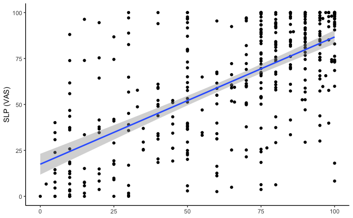

```r
slpMeasuresPlot <- slp_Correlation %>%
  ggplot() +
  aes(x = slp_EST,
      y = slp_VAS) +
  geom_point() +
  geom_smooth(method = "lm",
              se = T) +
  ylab("SLP (VAS)") +
  xlab("SLP (EST)") +
  labs(color = "SLP Rating Method") +
  scale_color_manual(values = my_pal) +
  theme_classic() +
  theme(legend.position = "bottom",
        axis.title.x=element_blank())

slpMeasuresPlot
```

## Plot of 4 Int Ratings

```r
intRatings_Long1 <- IntSpeakerRatings %>%
  dplyr::select(SpeakerID, slp_VAS, slp_EST) %>%
  pivot_longer(cols = slp_EST:slp_VAS,
               names_to = "RatingType",
               values_to = "Ratings")

intRatings_Long1 <- slp_Correlation %>%
  dplyr::rename(SpeakerID = Speaker) %>%
  dplyr::select(SpeakerID, slp_VAS, slp_EST) %>%
  pivot_longer(cols = slp_EST:slp_VAS,
               names_to = "RatingType",
               values_to = "Ratings")

intRatings_Long2 <- naive_Correlation %>%
  dplyr::select(SpeakerID, naive_VAS, naive_OT) %>%
    pivot_longer(cols = naive_VAS:naive_OT,
               names_to = "RatingType",
               values_to = "Ratings")

intRatings_Long <- base::rbind(intRatings_Long1, intRatings_Long2) %>%
  dplyr::mutate(RatingType = as.factor(RatingType)) %>%
  dplyr::mutate(RatingType = recode_factor(RatingType,
                                           "naive_VAS" = "Naive (VAS)",
                                           "naive_OT" = "Naive (Transcriptions)",
                                           "slp_VAS" = "SLP (VAS)",
                                           "slp_EST" = "SLP (Estimations)")) %>%
  dplyr::mutate(RatingType = fct_relevel(RatingType,
                                                "Naive (Transcriptions)",
                                                "Naive (VAS)",
                                                "slp_VAS" = "SLP (VAS)",
                                                "slp_EST" = "SLP (Estimations)"))


library(extrafont) # install.packages('extrafont')
## custom colors
my_pal <- rcartocolor::carto_pal(n = 7, name = "Teal")[c(7, 5, 3, 2, 4)]

## Theme ----
theme_set(theme_void(base_family = "Roboto"))

theme_update(
  axis.text.x = element_text(color = "black", face = "bold", size = 26,
                             margin = margin(t = 6)),
  axis.text.y = element_text(color = "black", size = 22, hjust = 1,
                             margin = margin(r = 6), family = "Roboto Mono"),
  axis.line.x = element_line(color = "black", size = 1),
  panel.grid.major.y = element_line(color = "grey90", size = .6),
  plot.background = element_rect(fill = "white", color = "white"),
  plot.margin = margin(rep(20, 4))
)


# Difference Plots: Word Trans ----
ggplot(data = intRatings_Long,
       aes(x = RatingType,
           y = Ratings,
           color = RatingType,
           fill = RatingType)) +
  ggdist::stat_halfeye(
    adjust = 1.3,
    width = .6,
    .width = 0,
    justification = -.2,
    point_colour = NA,
    outline_bars = T
  ) +
  scale_alpha_discrete(range = c(.4,.9), guide = "none") +
  geom_boxplot(
    width = .15,
    outlier.shape = NA,
    fill = "white"
  ) +
  ## add justified jitter from the {gghalves} package
  gghalves::geom_half_point(
    ## draw jitter on the left
    side = "l",
    ## control range of jitter
    range_scale = .4,
    ## add some transparency
    alpha = .3
  ) +
  coord_cartesian(xlim = c(0, 100), clip = "off") +
  coord_flip() +
  scale_color_manual(values = my_pal, guide = "none") +
  scale_fill_manual(values = my_pal, guide = "none") +
  labs(title = "Intelligibility Ratings") +
  ylab("Intelligibility") +
  xlab("") +
  theme_classic() +
  theme(plot.title = element_text(hjust = 0.5)) +
  theme(text=element_text(size = 13,
        family="Arial Bold"))
```

```
Using alpha for a discrete variable is not advised.Coordinate system already present. Adding new coordinate system, which will replace the existing one.
```

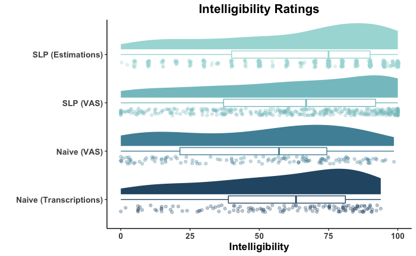

```r
ggsave("Plots/IntRatingsDistribution.png", plot = last_plot(),height = 5, width = 7, units = "in", scale = .8)
```

# Research Question #3

Q3: Is there a strong relationship between naive listener OT scores with their VAS intelligibility estimation?

```r
rmcorr::rmcorr(ListenerID, naive_OT, naive_VAS, naive_Correlation)
```

```
Repeated measures correlation

r
0.8882485

degrees of freedom
69

p-value
5.242799e-25

95% confidence interval
0.825011 0.9295159
```

# Research Question #4

Q4: How reliable are these intelligibility measures (VAS ratings, approximations, and OT scores), as determined by intrarater and interrater agreement?

```r
#IntraRater Reliability for the SLPs VAS Rating
slpVAS_Intra <- slp_Correlation %>%
  dplyr::select(c(slp_VAS, slp_VAS.Rel)) %>%
  dplyr::filter(slp_VAS.Rel != "")

slpVAS_IntraCorr <- slpVAS_Intra %>%
  corrr::correlate()
```

```
Correlation method: 'pearson'
Missing treated using: 'pairwise.complete.obs'
```

```r
slpVAS_IntraCorr
```

| term | slp_VAS | slp_VAS.Rel |
| --- | --- | --- |
| slp_VAS | NA | 0.870219 |
| slp_VAS.Rel | 0.870219 | NA |

```r
cor.test(slp_Correlation$slp_VAS, slp_Correlation$slp_VAS.Rel, method = "pearson", use = "complete.obs")
```

```
    Pearson's product-moment correlation

data:  slp_Correlation$slp_VAS and slp_Correlation$slp_VAS.Rel
t = 15.297, df = 75, p-value < 2.2e-16
alternative hypothesis: true correlation is not equal to 0
95 percent confidence interval:
 0.8026937 0.9157152
sample estimates:
     cor
0.870219
```

```r
#IntraRater Reliability for the SLPs EST Rating
slpEST_Intra <- slp_Correlation %>%
  dplyr::select(c(slp_EST, slp_EST.Rel)) %>%
  dplyr::filter(slp_EST.Rel != "")

slpEST_IntraCorr <- slpEST_Intra %>%
  corrr::correlate()
```

```
Correlation method: 'pearson'
Missing treated using: 'pairwise.complete.obs'
```

```r
slpEST_IntraCorr
```

| term | slp_EST | slp_EST.Rel |
| --- | --- | --- |
| slp_EST | NA | 0.8509701 |
| slp_EST.Rel | 0.8509701 | NA |

```r
cor.test(slp_Correlation$slp_EST, slp_Correlation$slp_EST.Rel, method = "pearson", use = "complete.obs")
```

```
    Pearson's product-moment correlation

data:  slp_Correlation$slp_EST and slp_Correlation$slp_EST.Rel
t = 14.672, df = 82, p-value < 2.2e-16
alternative hypothesis: true correlation is not equal to 0
95 percent confidence interval:
 0.7786314 0.9009859
sample estimates:
      cor
0.8509701
```

```r
#Interrater Reliability for the SLPs VAS rating
slpVAS_Inter <- slp_Correlation %>%
  dplyr::select(!c(slp_VAS.Rel, slp_EST, slp_EST.Rel))

slpVAS_Inter_wide <- tidyr::pivot_wider(slpVAS_Inter, names_from = slpID, values_from = slp_VAS)

slpVAS_Inter_wide <- slpVAS_Inter_wide %>%
  dplyr::select(!Speaker)

k <- 1
while(k <= ncol(slpVAS_Inter_wide)){
  slpVAS_Inter_wide[is.na(slpVAS_Inter_wide[,k]), k] <- colMeans(slpVAS_Inter_wide[,k], na.rm = TRUE)
  k <- k + 1
}

irr::icc(slpVAS_Inter_wide, model = "twoway",
  type="agreement",
  unit="average", r0=0, conf.level=0.95)
```

```
 Average Score Intraclass Correlation

   Model: twoway
   Type : agreement

   Subjects = 20
     Raters = 21
  ICC(A,21) = 0.961

 F-Test, H0: r0 = 0 ; H1: r0 > 0
  F(19,132) = 37.6 , p = 5.35e-44

 95%-Confidence Interval for ICC Population Values:
  0.929 < ICC < 0.982
```

```r
irr::icc(slpVAS_Inter_wide, model = "twoway",
  type="agreement",
  unit="single", r0=0, conf.level=0.95)
```

```
 Single Score Intraclass Correlation

   Model: twoway
   Type : agreement

   Subjects = 20
     Raters = 21
   ICC(A,1) = 0.54

 F-Test, H0: r0 = 0 ; H1: r0 > 0
  F(19,138) = 37.6 , p = 4.83e-45

 95%-Confidence Interval for ICC Population Values:
  0.385 < ICC < 0.723
```

```r
#Interrater Reliability for the SLPs EST rating
slpEST_Inter <- slp_Correlation %>%
  dplyr::select(!c(slp_EST.Rel, slp_VAS, slp_VAS.Rel))

slpEST_Inter_wide <- tidyr::pivot_wider(slpEST_Inter, names_from = slpID, values_from = slp_EST)

slpEST_Inter_wide <- slpEST_Inter_wide %>%
  dplyr::select(!Speaker)

irr::icc(slpEST_Inter_wide, model = "twoway",
  type="agreement",
  unit="average", r0=0, conf.level=0.95)
```

```
 Average Score Intraclass Correlation

   Model: twoway
   Type : agreement

   Subjects = 20
     Raters = 21
  ICC(A,21) = 0.964

 F-Test, H0: r0 = 0 ; H1: r0 > 0
  F(19,156) = 39 , p = 2.31e-49

 95%-Confidence Interval for ICC Population Values:
  0.936 < ICC < 0.984
```

```r
irr::icc(slpEST_Inter_wide, model = "twoway",
  type="agreement",
  unit="single", r0=0, conf.level=0.95)
```

```
 Single Score Intraclass Correlation

   Model: twoway
   Type : agreement

   Subjects = 20
     Raters = 21
   ICC(A,1) = 0.563

 F-Test, H0: r0 = 0 ; H1: r0 > 0
  F(19,161) = 39 , p = 2.25e-50

 95%-Confidence Interval for ICC Population Values:
  0.41 < ICC < 0.74
```

## Plots Modeling slpEST and slpVAS to naive OT and naive VAS

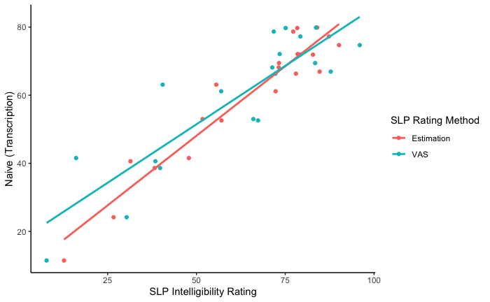

```r
IntSpeakerRatings_Long <- tidyr::pivot_longer(IntSpeakerRatings,
                                              cols = slp_EST:slp_VAS,
                                              names_to = "Method",
                                              values_to = "rating")

IntSpeakerRatings_Long <- IntSpeakerRatings_Long %>%
  dplyr::mutate(Method = recode(Method, slp_EST = "Estimation", slp_VAS = "VAS"))

NaiveOT_plot <- IntSpeakerRatings_Long %>%
  ggplot() +
  aes(x = rating,
      y = naive_OT,
      color = Method) +
  geom_point() +
  geom_smooth(method = "lm", se = F) +
  xlab("SLP Intelligibility Rating") +
  ylab("Naive (Transcription)") +
  labs(color = "SLP Rating Method") +
  theme_classic()

NaiveOT_plot
```

## Naive VAS plot

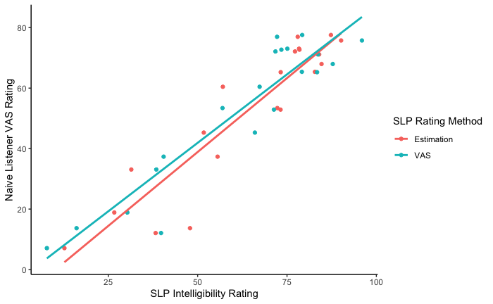

```r
NaiveVAS_plot <- IntSpeakerRatings_Long %>%
  ggplot() +
  aes(x = rating,
      y = naive_VAS,
      color = Method) +
  geom_point() +
  geom_smooth(method = "lm", se = F) +
  xlab("SLP Intelligibility Rating") +
  ylab("Naive Listener VAS Rating") +
  labs(color = "SLP Rating Method") +
  theme_classic()

NaiveVAS_plot
```

## Combining RQ1 plot and exporting

```r
RQ1_Plot <- ggpubr::ggarrange(NaiveOT_plot, NaiveVAS_plot, ncol = 2, labels = c("A", "B"), nrow = 1, common.legend = T, legend = "bottom")
RQ1_Plot
```

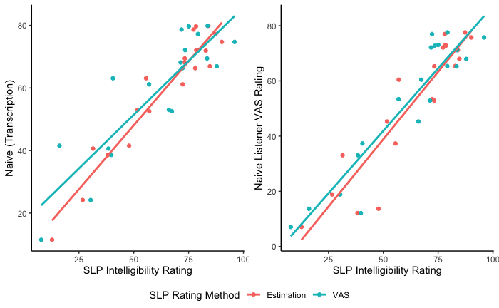

```r
ggsave(filename = "Plots/RQ1_Plot.png", plot = RQ1_Plot, height = 5, width = 10, unit = "in")
```

## Creating Mean SLP Int plot

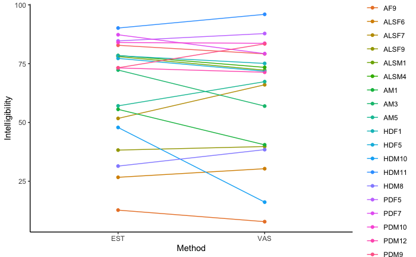

```r
MeanInt_plot <- MeanSLPInt %>%
  ggplot() +
  aes(x = Method,
      y = Intelligibility,
      group = Speaker,
      color = Speaker) +
  geom_point() +
  geom_line() +
  theme_classic()

MeanInt_plot

ggsave(filename = "Plots/SpeakerInt_Plot.png", plot = MeanInt_plot, height = 10, width = 10, unit = "in")
```

# Monster Plot - Facet Wrap

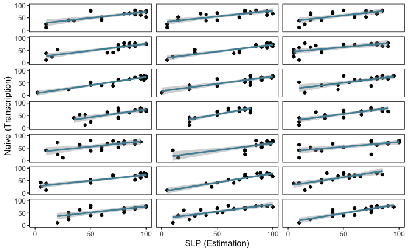

```r
monsterPlotData1 <- IntSpeakerRatings %>%
  dplyr::select(SpeakerID, naive_OT)

monsterPlotData2 <- slp_Correlation %>%
  dplyr::rename(SpeakerID = Speaker) %>%
  dplyr::select(slpID, SpeakerID, slp_EST, slp_VAS)

monsterPlotData <- base::merge(monsterPlotData1, monsterPlotData2, all = T)

rm(monsterPlotData1,monsterPlotData2)

## custom colors
my_pal <- rcartocolor::carto_pal(n = 7, name = "Teal")[c(7, 4, 3, 2, 5)]

monsterPlot_long <- monsterPlotData %>%
  ggplot() +
  aes(x = slp_EST,
      y = naive_OT) +
  geom_point() +
  geom_smooth(method = "lm",
              color=my_pal[5],
              se = T) +
  theme_classic() +
  ylab("Naive (Transcription)") +
  xlab("SLP (Estimation)") +
  scale_color_manual(values = my_pal) +
  scale_x_continuous(breaks = scales::pretty_breaks(n = 3)) +
  scale_y_continuous(breaks = scales::pretty_breaks(n = 3)) +
  facet_wrap(facets = "slpID", ncol = 3) +
  theme(panel.border = element_rect(color="black", fill=NA)) +
 theme(strip.text.x = element_blank())

monsterPlot_long

ggsave("Plots/MonsterPlo_long.png", plot = last_plot(),height = 14, width = 6.8, units = "in", scale = .4)
```

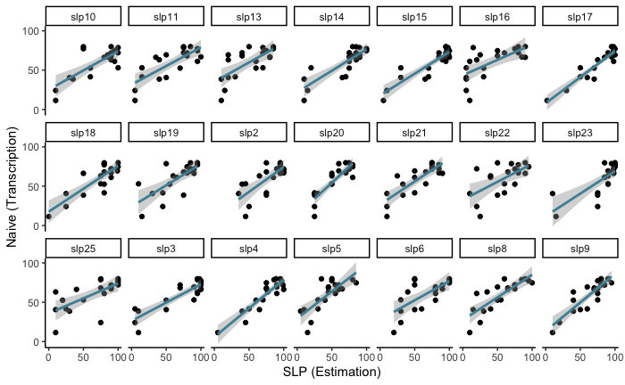

```r
monsterPlot_wide <- monsterPlotData %>%
  ggplot() +
  aes(x = slp_EST,
      y = naive_OT) +
  geom_point() +
  geom_smooth(method = "lm",
              color=my_pal[5],
              se = T) +
  theme_classic() +
  ylab("Naive (Transcription)") +
  xlab("SLP (Estimation)") +
  scale_color_manual(values = my_pal) +
  scale_x_continuous(breaks = scales::pretty_breaks(n = 3)) +
  scale_y_continuous(breaks = scales::pretty_breaks(n = 3)) +
  facet_wrap(facets = "slpID", ncol = 7)

monsterPlot_wide

ggsave("Plots/MonsterPlo_wide.png", plot = last_plot(),height = 6.8, width = 14, units = "in", scale = .4)
```

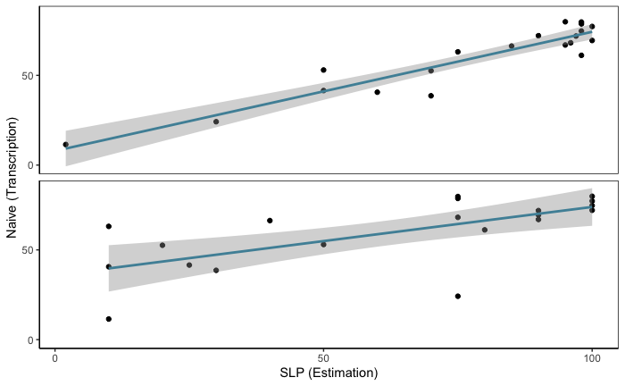

```r
SLP_plot <- monsterPlotData %>%
  dplyr::filter(slpID == "slp17" | slpID == "slp25") %>%
  ggplot() +
  aes(x = slp_EST,
      y = naive_OT) +
  geom_point() +
  geom_smooth(method = "lm",
              color=my_pal[5],
              se = T) +
  theme_classic() +
  ylab("Naive (Transcription)") +
  xlab("SLP (Estimation)") +
  scale_color_manual(values = my_pal) +
  scale_x_continuous(breaks = scales::pretty_breaks(n = 3)) +
  scale_y_continuous(breaks = scales::pretty_breaks(n = 3)) +
  facet_wrap(facets = "slpID", ncol = 1) +
  theme(panel.border = element_rect(color="black", fill=NA)) +
 theme(strip.text.x = element_blank())

SLP_plot

ggsave("Plots/SLP_plot.png", plot = last_plot(),height = 10, width = 5.2, units = "in", scale = .4)
```